# assignment_02

```r
# set up libraries
library(data.table)
library(tidyverse)
```

## Data Wrangling

```r
# read datasets
individual <- read.csv("chs_individual.csv")
regional <- read.csv("chs_regional.csv")
```

```r
# check the dimension
dim(individual)
```

```
## [1] 1200   23
```

```r
dim(regional)
```

```
## [1] 12 27
```

```r
# merge datasets
CHS_data <-merge(
  # Data
  x     = individual,
  y     = regional,
  # List of variables to match
  by.x  = "townname",
  by.y  = "townname",
  # Which obs to keep?
  all.x = TRUE,
  all.y = FALSE
  )
```

#### Question 1

```r
# check the number of rows and columns for merge data
dim(CHS_data)
```

```
## [1] 1200   49
```

**Since the individual data contains 1200 rows and 23 variables, the regional data contains 12 rows and 27 variables, so the merge data should have 1200 rows and (23+27-1) vairables, which is 49 variables. Our merge data (CHS_data) exactly contains 1200 rows and 49 variables.**

```r
# check the which variable has missing data
names(which(colSums(is.na(CHS_data))>0))
```

```
##  [1] "agepft"        "height"        "weight"        "bmi"
##  [5] "asthma"        "father_asthma" "mother_asthma" "wheeze"
##  [9] "hayfever"      "allergy"       "educ_parent"   "smoke"
## [13] "gasstove"      "fev"           "fvc"           "mmef"
## [17] "no_24hr"       "pm2_5_fr"
```

```r
# In the case of missing values, impute data using the average within the variables “male” and “hispanic.”
CHS_data <- data.table(CHS_data)
CHS_data[, bmi_imp := fcoalesce(bmi, mean(bmi, na.rm = TRUE)), by = .(male, hispanic)]
CHS_data[, fev_imp := fcoalesce(fev, mean(fev, na.rm = TRUE)), by = .(male, hispanic)]
```

```r
# check whether the miss data in the bmi_imp is replaced by average
CHS_data[is.na(bmi), table(bmi_imp)]
```

```
## bmi_imp
## 18.0528132385175 18.1403488975538 18.6320136289228 19.4114827856583
##               34               20               18               17
```

```r
CHS_data[!is.na(bmi)] %>%
  group_by(male,hispanic) %>%
  summarize(bmi = mean(bmi))
```

```
## # A tibble: 4 × 3
## # Groups:   male [2]
##    male hispanic   bmi
##   <int>    <int> <dbl>
## 1     0        0  18.1
## 2     0        1  18.6
## 3     1        0  18.1
## 4     1        1  19.4
```

```r
# check whether the miss data in the fev_imp is replaced by average
CHS_data[is.na(fev), table(fev_imp)]
```

```
## fev_imp
## 1945.74348054707 1977.24143415372 2090.25847716389   2120.266131997
##               36               20               22               17
```

```r
CHS_data[!is.na(fev)] %>%
  group_by(male,hispanic) %>%
  summarize(fev = mean(fev))
```

```
## # A tibble: 4 × 3
## # Groups:   male [2]
##    male hispanic   fev
##   <int>    <int> <dbl>
## 1     0        0 1946.
## 2     0        1 1977.
## 3     1        0 2090.
## 4     1        1 2120.
```

#### Question 2

```r
# Create a new categorical variable named “obesity_level” using the BMI measurement
CHS_data[, obesity_level := fifelse(bmi_imp <14, "underweight",
                        fifelse(bmi_imp >=14 & bmi_imp <= 22, "normal",
                               fifelse(bmi_imp >22 & bmi_imp <= 24, "normal", "obese")))]
```

```r
# create a summary table that contains the minimum BMI, maximum BMI, and the total number of observations per category
summary(CHS_data$bmi_imp)
```

```
##    Min. 1st Qu.  Median    Mean 3rd Qu.    Max.
##   11.30   15.96   17.81   18.50   19.99   41.27
```

```r
table(CHS_data$obesity_level)
```

```
##
##      normal       obese underweight
##        1062         103          35
```

#### Question 3

```r
# Create another categorical variable named “smoke_gas_exposure” that summarizes “Second Hand Smoke” and “Gas Stove.”
CHS_data[, smoke_gas_exposure := fifelse(smoke == 1 & gasstove == 1, "expose both",
                        fifelse(smoke == 1 & gasstove != 1, "expose second hand smoke only",
                               fifelse(smoke != 1 & gasstove == 1, "expose gas stove only", "neither")))]
```

```r
# check the total number of observations per category
table(CHS_data$smoke_gas_exposure)
```

```
##
##                   expose both         expose gas stove only
##                           151                           739
## expose second hand smoke only                       neither
##                            36                           214
```

#### Question 4

```r
# Create four summary tables showing the average (or proportion, if binary) and sd of “Forced expiratory volume in 1 second (ml)” and asthma indicator by town, sex, obesity level, and “smoke_gas_exposure.”

# By town
summary_town <- CHS_data[, .(
    fev_avg      = mean(fev_imp, na.rm=TRUE),
    fev_sd       = sd(fev_imp, na.rm=TRUE),
    asthma_avg   = mean(asthma, na.rm=TRUE),
    asthma_sd    = sd(asthma, na.rm=TRUE)
    ),
    by = townname
    ][order(townname)] %>% head(n = 4)
summary_town
```

```
##         townname  fev_avg   fev_sd asthma_avg asthma_sd
## 1:        Alpine 2087.101 291.1768  0.1134021 0.3187308
## 2:    Atascadero 2075.897 324.0935  0.2551020 0.4381598
## 3: Lake Elsinore 2038.849 303.6956  0.1263158 0.3339673
## 4:  Lake Gregory 2084.700 319.9593  0.1515152 0.3603750
```

```r
# By sex
summary_sex <- CHS_data[, .(
    fev_avg      = mean(fev_imp, na.rm=TRUE),
    fev_sd       = sd(fev_imp, na.rm=TRUE),
    asthma_avg   = mean(asthma, na.rm=TRUE),
    asthma_sd    = sd(asthma, na.rm=TRUE)
    ),
    by = male
    ][order(male)] %>% head(n = 4)
summary_sex
```

```
##    male  fev_avg   fev_sd asthma_avg asthma_sd
## 1:    0 1958.911 311.9181  0.1208054 0.3261747
## 2:    1 2103.787 307.5123  0.1727749 0.3783828
```

```r
# By obesity level
summary_obesity_level <- CHS_data[, .(
    fev_avg      = mean(fev_imp, na.rm=TRUE),
    fev_sd       = sd(fev_imp, na.rm=TRUE),
    asthma_avg   = mean(asthma, na.rm=TRUE),
    asthma_sd    = sd(asthma, na.rm=TRUE)
    ),
    by = obesity_level
    ][order(obesity_level)] %>% head(n = 4)
summary_obesity_level
```

```
##    obesity_level  fev_avg   fev_sd asthma_avg asthma_sd
## 1:        normal 2018.187 303.2454 0.14216634 0.3493897
## 2:         obese 2266.154 325.4710 0.21000000 0.4093602
## 3:   underweight 1698.327 303.3983 0.08571429 0.2840286
```

```r
# By smoke_gas_exposure
summary_smoke_gas_exposure <- CHS_data[, .(
    fev_avg      = mean(fev_imp, na.rm=TRUE),
    fev_sd       = sd(fev_imp, na.rm=TRUE),
    asthma_avg   = mean(asthma, na.rm=TRUE),
    asthma_sd    = sd(asthma, na.rm=TRUE)
    ),
    by = smoke_gas_exposure
    ][order(smoke_gas_exposure)] %>% head(n = 4)
summary_smoke_gas_exposure
```

```
##               smoke_gas_exposure  fev_avg   fev_sd asthma_avg asthma_sd
## 1:                   expose both 2019.867 298.9728  0.1301370 0.3376123
## 2:         expose gas stove only 2025.989 317.6305  0.1477428 0.3550878
## 3: expose second hand smoke only 2055.714 295.6475  0.1714286 0.3823853
## 4:                       neither 2055.356 330.4169  0.1476190 0.3555696
```

## Looking at the Data (EDA)

#### Question 1

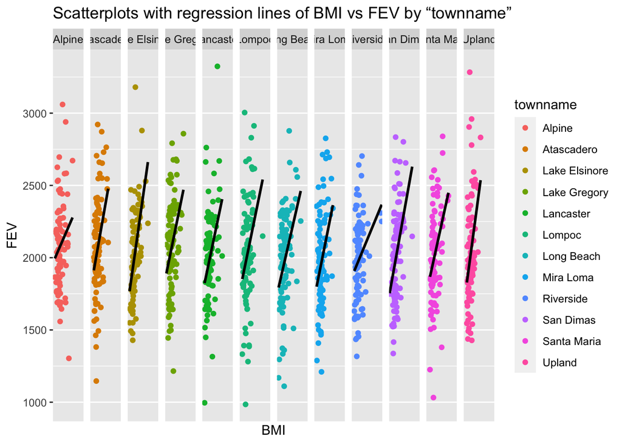

```r
# Facet plot showing scatterplots with regression lines of BMI vs FEV by “townname”
library(ggplot2)

facet_plot <- CHS_data %>%
  ggplot(mapping = aes(x = bmi_imp, y = fev_imp)) +
  geom_point(mapping = aes(color=townname)) +
  geom_smooth(method = "lm", se=FALSE, color="black", formula = y ~ x) +
  facet_wrap(~ townname, nrow = 1) +
  scale_x_discrete(guide = guide_axis(n.dodge=3))+
  labs(x = "BMI", y = "FEV", title = "Scatterplots with regression lines of BMI vs FEV by “townname”")
facet_plot
```

**BMI and FEV are positively correlation**

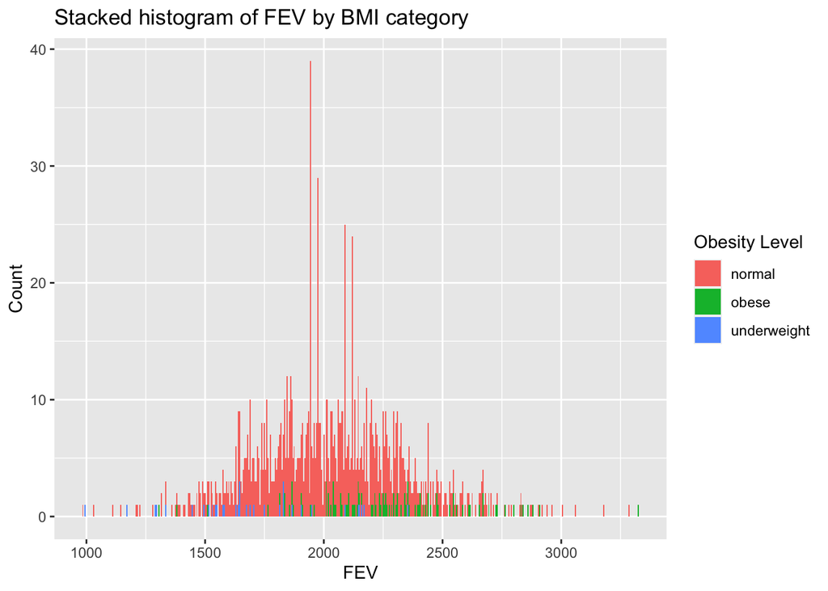

```r
# Stacked histograms of FEV by BMI category and FEV by smoke/gas exposure. Use different color schemes than the ggplot default

# BMI category
hist1 <- CHS_data %>%
  ggplot(aes(fev_imp, fill = obesity_level)) +
  geom_histogram(binwidth = 5) +
  scale_fill_discrete(name = "Obesity Level") +
  labs(x = "FEV", y = "Count", title = "Stacked histogram of FEV by BMI category")
hist1
```

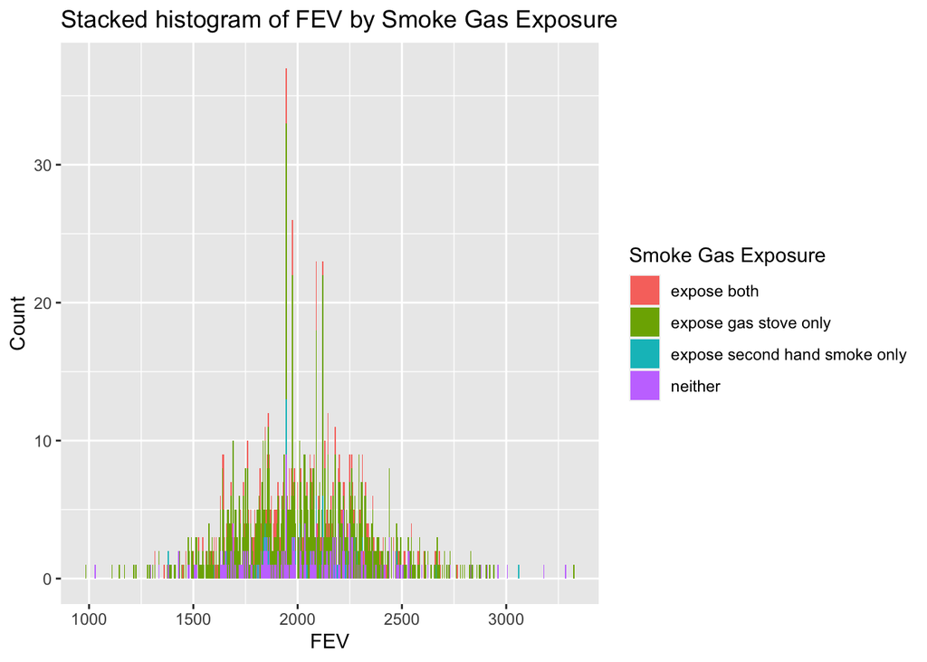

```r
# smoke/gas exposure
hist2 <- CHS_data[!is.na(smoke_gas_exposure)] %>%
  ggplot(aes(fev_imp, fill = smoke_gas_exposure)) +
  geom_histogram(binwidth = 5) +
  scale_fill_discrete(name = "Smoke Gas Exposure") +
  labs(x = "FEV", y = "Count", title = "Stacked histogram of FEV by Smoke Gas Exposure")
hist2
```

**Both graphs show the nearly normal distribution.**

#### Question 3

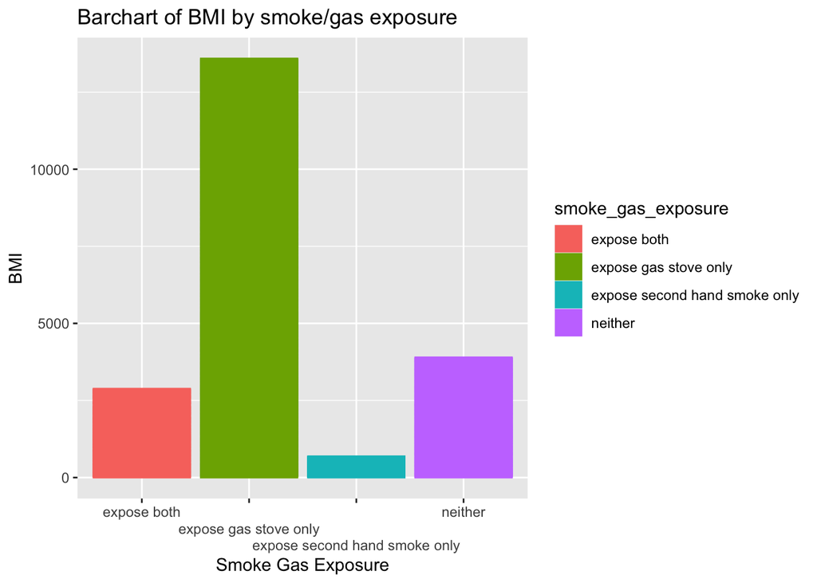

```r
# Barchart of BMI by smoke/gas exposure
barchart <- CHS_data[!is.na(smoke_gas_exposure)] %>%
  ggplot(mapping = aes(y = bmi_imp, x = smoke_gas_exposure)) +
  geom_col(mapping = aes(colour = smoke_gas_exposure, fill = smoke_gas_exposure)) +
  scale_x_discrete(guide = guide_axis(n.dodge=3))+
  labs(x = "Smoke Gas Exposure", y = "BMI", title = "Barchart of BMI by smoke/gas exposure")
barchart
```

#### Question 4

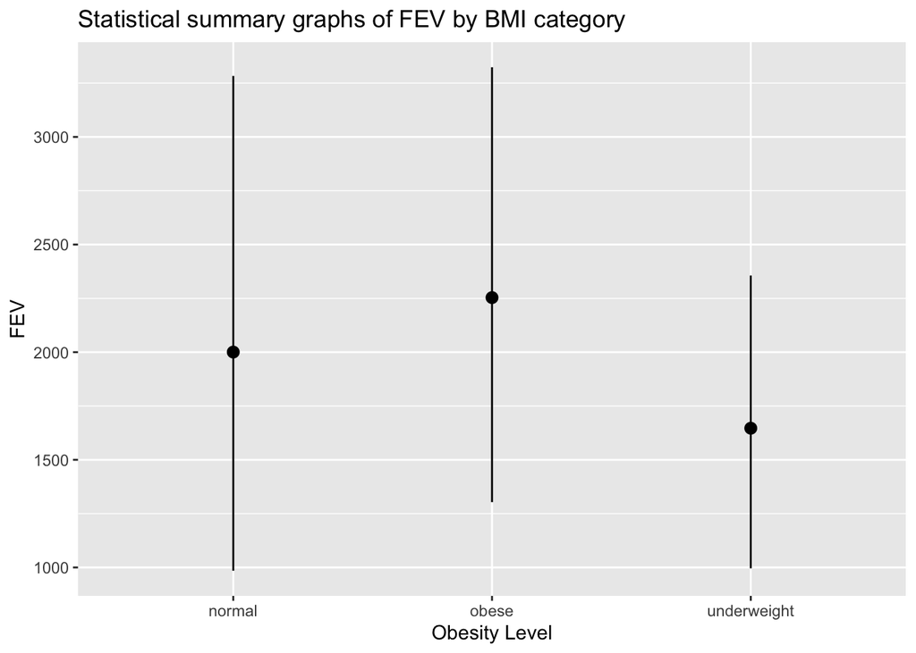

```r
# Statistical summary graphs of FEV by BMI and FEV by smoke/gas exposure category

# by BMI
stat1 <- CHS_data %>%
ggplot() +
    stat_summary(mapping = aes(x = obesity_level, y = fev_imp),
    fun.min = min,
    fun.max = max,
    fun = median,) +
  labs(x = "Obesity Level", y = "FEV", title = "Statistical summary graphs of FEV by BMI category")
stat1
```

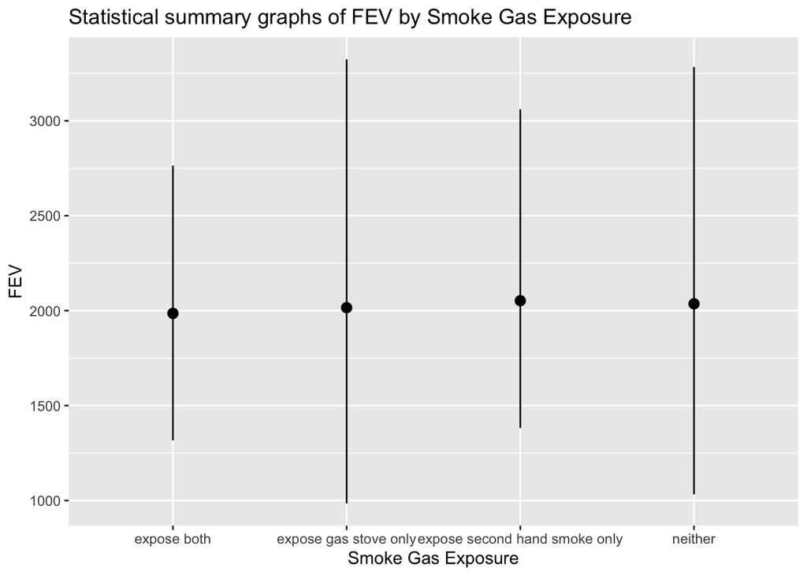

```r
# by smoke/gas exposure category
stat2 <- CHS_data[!is.na(smoke_gas_exposure)] %>%
ggplot() +
    stat_summary(mapping = aes(x = smoke_gas_exposure, y = fev_imp),
    fun.min = min,
    fun.max = max,
    fun = median,) +
  labs(x = "Smoke Gas Exposure", y = "FEV", title = "Statistical summary graphs of FEV by Smoke Gas Exposure")
stat2
```

**Obese children have higher FEV than other two categories. When it comes to the smoke gas exposure, all categories have the almost same median, but the ranges for children expose second hand smoke only and expose both are smaller**

#### Question 5

```r
# A leaflet map showing the concentrations of PM2.5 mass in each of the CHS communities.
library(leaflet)
# Generating a color palette
pal <- colorFactor(c('blue','red'), domain=CHS_data$pm25_mass)

leafletmap <- leaflet(CHS_data) %>%
  # The looks of the Map
  addProviderTiles('CartoDB.Positron') %>%
  # Some circles
  addCircles(
    lat = ~lat, lng=~lon,
    label = ~paste0(pm25_mass, ' C'), color = ~ pal(pm25_mass),
    opacity = 1, fillOpacity = 1, radius = 2
    ) %>%
  # And a pretty legend
  addLegend('bottomleft', pal=pal, values=CHS_data$pm25_mass,
          title='PM2.5 mass')

leafletmap
```

[interactive chart not shown]

**Cities near Los Angeles (especially near Pasadena) have much higher PM2.5 mass, whereas cities near Santa Barbara (near sea) contain less PM2.5 mass**

#### Question 6

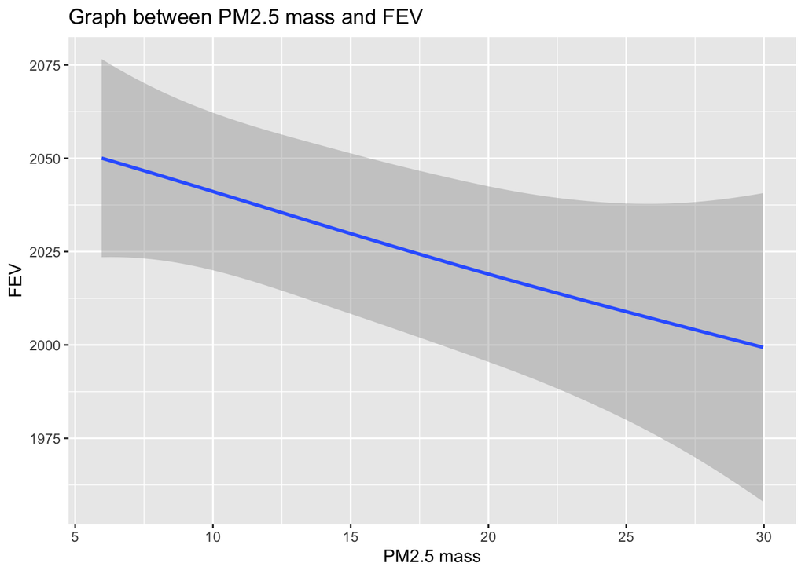

```r
# Use geometric objects
geo <- CHS_data[!is.na(smoke_gas_exposure)] %>%
  ggplot() +
  geom_smooth(method = 'gam', mapping = aes(x = pm25_mass, y = fev_imp))+
  labs(x = "PM2.5 mass", y = "FEV", title = "Graph between PM2.5 mass and FEV")
geo
```

**We could see that with the increase of PM2.5 mass, FEV decreases. meaning that they have the negative correlation**

### Conclusion

**What is the association between BMI and FEV (forced expiratory volume)**

BMI and FEV have a positive relationship. Higher BMI, higher FEV

**What is the association between smoke and gas exposure and FEV?**

Smoke and gaas exposure forms the normal distribution with FEV. When FEV is around the median value, the number of children under four categories is at most. In addition, there is no big difference of the relationship between FEV and different categories in smoke and gas exposure

**What is the association between PM2.5 exposure and FEV**

They have the negative correlation. More PM2.5 exposure, less FEV